# DDoS Attack Mitigation

# Overview

TODO: Revise Jain’s principles and common mistakes.

TODO: Outline the rest of the work.

## Parameters

### Dataset

TODO: Introduce the dataset.

We used a dataset with 2^24 packets in the detection phase.

### Sensitivity Coefficients

TODO: Explain.

What are our chosen k coefficients?

Our experiments with tcad_m_levels.py show us candidate values for k, as follows:

| Log2(m) | k | FPR |
| --- | --- | --- |
| 14 | 4.125 | 1.7% |
| 16 | 4.500 | 1.6% |
| 18 | 3.625 | 0.0% |

### TCAD Traces

TODO: Explain.

[Source: DDoS Mitigation.ipynb, section Finding TCAD Values]

TCAD measurements can be found in the following files:

tcad_m_2_14_k_4.125.log tcad_m_2_16_k_4.500.log tcad_m_2_18_k_3.625.log

## Observation Window Numbers

**Note: When we preinitialize training coefficients, the length of the workload is equal to the length of the detection phase.**

For a detection phase of 2^24 packets we have:

2^(24-log2m-2) OWs before the attack, 2^(24-log2m-1) OWs under attack, 2^(24-log2m-2) OWs after the attack.

2^8 OWs pre-attack and post attack,  
2^9 OWs under attack,

For m=2^16, 2^8 windows:

2^6 OWs pre-attack and post-attack, 2^7 OWs under attack.

For m=2^18, 2^6 windows:

2^4 OWs pre-attack and post-attack, 2^5 OWs under attack.

# Workload Characterization

## Reading TCAD Trace Files

```r
tcad_m14 = read_tcad_trace(tcad_m14_trace)
tcad_m16 = read_tcad_trace(tcad_m16_trace)
tcad_m18 = read_tcad_trace(tcad_m18_trace)
```

## Entropy Overview

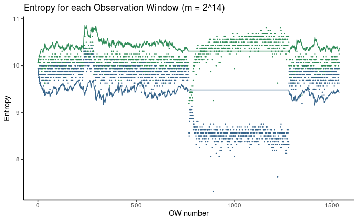

```r
title = "Entropy for each Observation Window "

get_plot_tcad(tcad_m14, tcad_m14_k) + labs(title=str_c(title,"(m = 2^14)"))
```

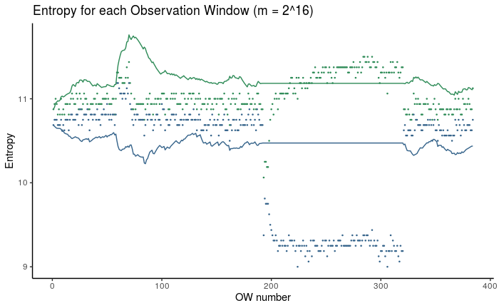

```r
get_plot_tcad(tcad_m16, tcad_m16_k) + labs(title=str_c(title,"(m = 2^16)"))
```

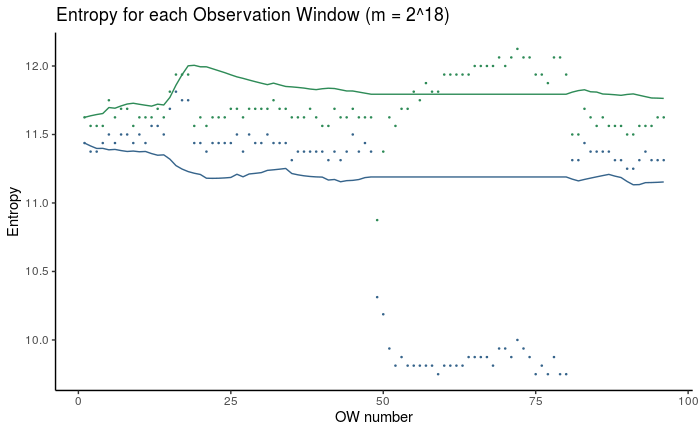

```r
get_plot_tcad(tcad_m18, tcad_m18_k) + labs(title=str_c(title,"(m = 2^18)"))
```

## Entropy Under Attack

We have the graph for the entire experiments. Now we need to focus in the attack.

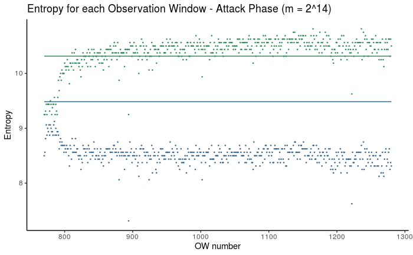

```r
title = "Entropy for each Observation Window - Attack Phase "

get_plot_tcad_attack(tcad_m14, tcad_m14_k, log2n, 14) + labs(title=str_c(title,"(m = 2^14)"))
```

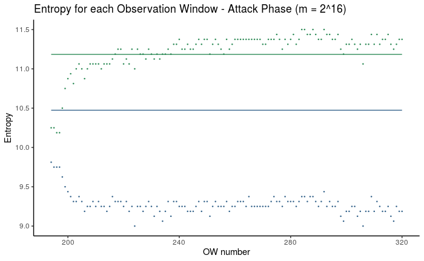

```r
get_plot_tcad_attack(tcad_m16, tcad_m16_k, log2n, 16) + labs(title=str_c(title,"(m = 2^16)"))
```

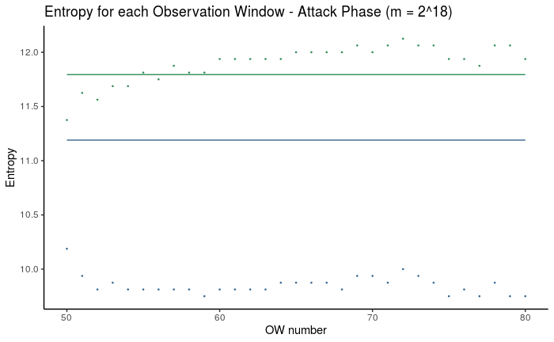

```r
get_plot_tcad_attack(tcad_m18, tcad_m18_k, log2n, 18) + labs(title=str_c(title,"(m = 2^18)"))
```

# Attack Mitigation

## Loading

```r
log2m = as.integer(16)

if (log2m == 14)  {
  pcap_csv = pcap_csv_m14
} else if (log2m == 16) {
  pcap_csv = pcap_csv_m16
} else if (log2m == 18) {
  pcap_csv = pcap_csv_m18
} else {
  stop("Invalid log2m value.")
}

attack_first_ow = attack_first(log2n, log2m) + 1 # Diversion begins at the second OW under attack.
attack_last_ow = attack_last(log2n, log2m)

packets = read_pcap_csv(log2n, log2m, pcap_csv) %>% filter(ow >= attack_first_ow, ow <= attack_last_ow)
```

## Typical Deltas

For each OW, what are the typical frequency deltas for attack packets?

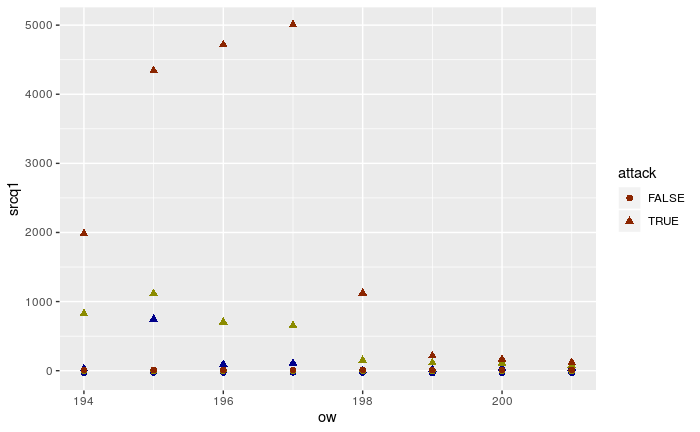

```r
deltas = summarize_deltas(log2n, log2m, packets)

dot_size = 2.0

if (log2m == 14)  {
  cut = attack_first_ow + 32
} else if (log2m == 16) {
  cut = attack_first_ow + 8
} else if (log2m == 18) {
  cut = attack_first_ow + 2
} else {
  stop("Invalid log2m value.")
}

delta_plot_options = list(
  geom_point(mapping = aes(y=srcq1), color="blue4", size=dot_size),
  geom_point(mapping = aes(y=srcq2), color="yellow4", size=dot_size),
  geom_point(mapping = aes(y=srcq3), color="orangered4", size=dot_size))

deltas %>% filter(ow<cut) %>%
  ggplot(mapping = aes(x=ow, shape=attack)) + delta_plot_options
```

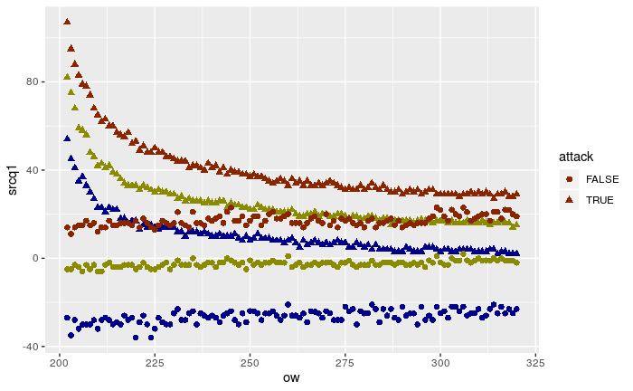

```r
deltas %>% filter(ow>=cut) %>%
  ggplot(mapping = aes(x=ow, shape=attack)) + delta_plot_options
```

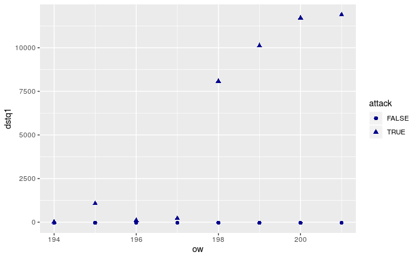

```r
delta_plot_options = list(
  geom_point(mapping = aes(y=dstq1), color="blue4", size=dot_size),
  geom_point(mapping = aes(y=dstq2), color="yellow4", size=dot_size),
  geom_point(mapping = aes(y=dstq3), color="orangered4", size=dot_size))

delta_plot_options = list(
  geom_point(mapping = aes(y=dstq1), color="blue4", size=dot_size))

deltas %>% filter(ow<cut) %>%
  ggplot(mapping = aes(x=ow, shape=attack)) + delta_plot_options
```

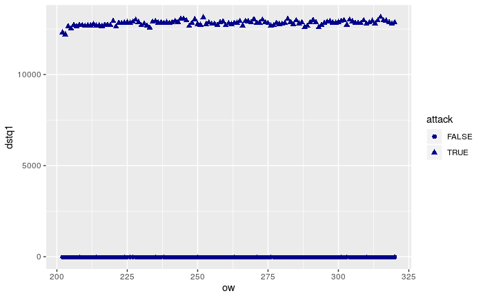

```r
deltas %>% filter(ow>=cut) %>%
  ggplot(mapping = aes(x=ow, shape=attack)) + delta_plot_options
```

```r
# deltas.long.good = melt(deltas %>% filter(attack == FALSE), id.vars="ow")
# deltas.long.evil = melt(deltas %>% filter(attack == TRUE), id.vars="ow")
#
# deltas.long.evil %>% filter(ow >= cut, str_detect(variable, "dstq")) %>%
# ggplot(aes(ow,value,color=variable)) + geom_point()
```

It would be cool to plot several box plots.

## Address Counts

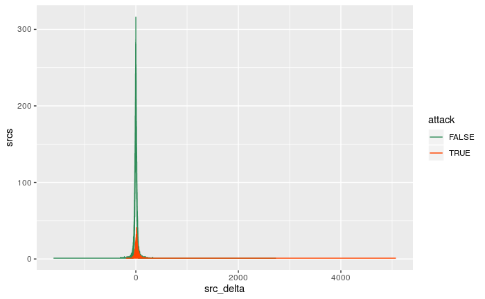

```r
graph_options = list(geom_line(), scale_color_manual(values=c("seagreen4", "orangered1")))

src_distinct = packets %>% group_by(ow, attack, src_delta) %>% summarize(srcs=n_distinct(src))
src_distinct %>% ggplot(aes(src_delta, srcs, color=attack)) + graph_options
```

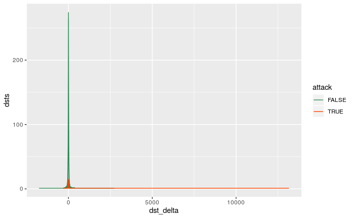

```r
dst_distinct = packets %>% group_by(ow, attack, dst_delta) %>% summarize(dsts=n_distinct(dst))
dst_distinct %>% ggplot(aes(dst_delta, dsts, color=attack)) + graph_options
```

## Classification

```r
if (log2m == 14) {
  src_threshold = 0
  dst_threshold = 16
} else if (log2m == 16) {
  src_threshold = 0
  dst_threshold = 32
} else if (log2m == 18) {
  src_threshold = 0
  dst_threshold = 64
} else {
  stop("Invalid log2m value.")
}

#divert = function(src_delta, dst_delta) (src_delta >= threshold)
#divert = function(src_delta, dst_delta) (dst_delta >= threshold)
#divert = function(src_delta, dst_delta) (src_delta >= threshold && dst_delta >= threshold)

divert = function(src_delta, dst_delta) (dst_delta >= dst_threshold)

packets = packets %>% mutate(diverted=divert(src_delta,dst_delta)) %>% group_by(ow)
```

## Statistics

Base Stats and Confidence Intervals

Both TPR and FPR are proportions whose values we need to estimate.

Let X be a random variable whose value is 1 when a classification succeeds, and 0 otherwise. Consequently, X follows a a Bernoulli distribution with probability p. We can use our sample to estimate the mean value of p. This sample mean has a sampling error approximately equal to sqrt(p * (1-p) / n), where n is the sample size (the total number of classification events).

```r
stats(packets, log2n, log2m)
```

```
True evil: 1664003 True good: 6659069 Total: 8323072
Class evil: 2519525 Class good: 5803547 Total: 8323072
FNcount: 48171 FPcount: 903693 Total: 951864
FNR: 0.0289 FPR: 0.1357
```

```r
stats_ci(packets, log2n, log2m)
```

```
TPR: 0.970694 ± 0.005699
FPR: 0.135721 ± 0.004297
```

## Graphs

It is interesting to observe what happens **over time**, OW after OW.

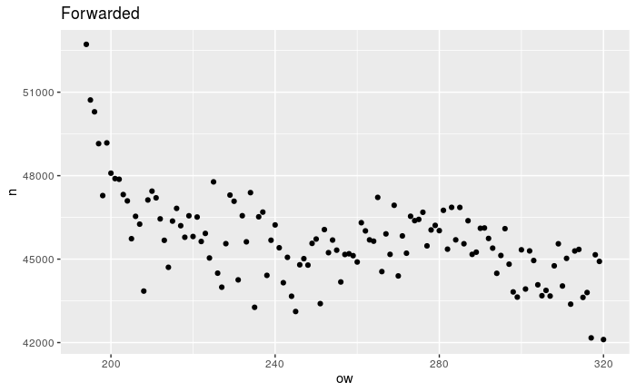

```r
#packets

#graph_actual_good(packets)
#graph_actual_evil(packets)
graph_marked_good(packets)
```

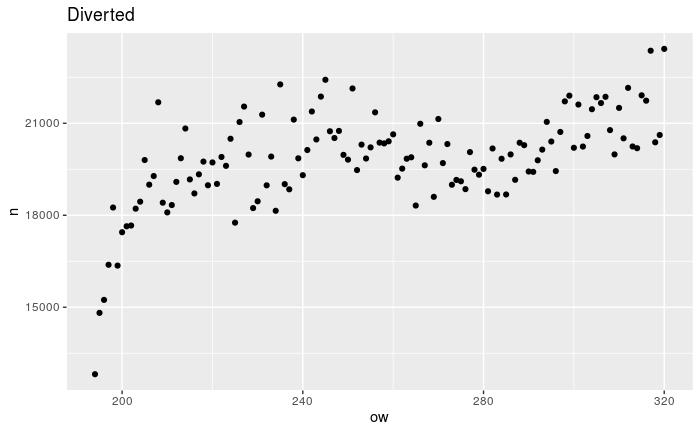

```r
graph_marked_evil(packets)
```

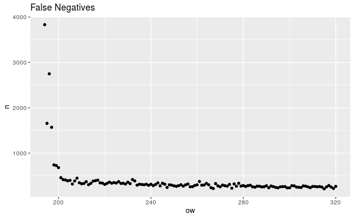

```r
graph_false_negatives(packets)
```

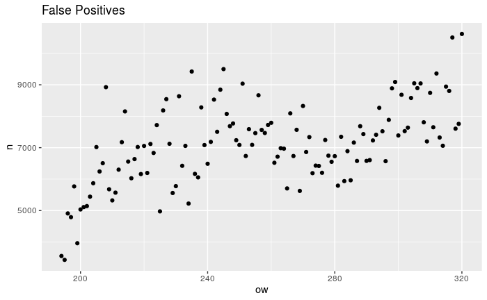

```r
graph_false_positives(packets)
```

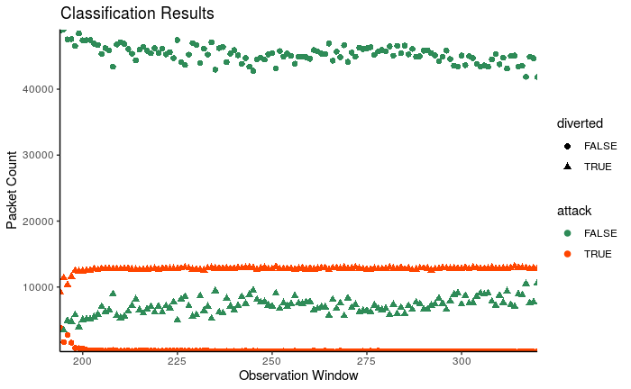

```r
graph_results(packets)
```

```r
NA
NA
```

Adjust scale, add legitimate and attack percentage lines.

# Points to Ponder

For each OW, how many different attack sources are there?

How do our findings correlate with TCAD measurements?

What else can we do?